# Interactome3D Analysis

Héctor Climente

10/18/2015

We used Interactome3D to study the effects of switches on real protein-protein interactions. If one of the isoforms of the switch is present in one interaction AND the other isoform only present has lost regions of the CDS due to the switch (no new CDS region), thne the switch is susceptible of being studied using I3D. If the other isoform gained any region, its consequences on the interaction would be more difficult to assess.

# Overview

```r
i3d <- read.delim(paste0(wd,"i3d_broken.tsv"),row.names=NULL)

i3d$DriverRelationship <- "No driver involved"
i3d$DriverRelationship[grep("Driver",i3d$Annotation)] <- "Driver"
i3d$DriverRelationship[grep("Driver",i3d$PartnerAnnotation)] <- "d1"
i3d$DriverRelationship[Reduce(intersect,  list(grep("Driver",i3d$Annotation),grep("Driver",i3d$PartnerAnnotation)))] <- "Driver-Driver"

# number of interactions
nrow(i3d)
```

```
## [1] 5821
```

```r
# number of unique interactions
nrow(unique(i3d[,c("Gene","normalTranscript","tumorTranscript","Partner")]))
```

```
## [1] 1190
```

```r
# i3d considers complete the structures that cover at least 80% of the sequence
i3d_complete <- i3d[i3d$SequenceCover>80 & i3d$PartnerCover>80,!colnames(i3d) %in% c("SequenceInformation","IsoformSpecific","PDB")]
i3d_complete_uniq <- unique(i3d_complete[,c("Symbol","Gene","Partner","normalTranscript","tumorTranscript","InteractionAffection","Annotation","PartnerAnnotation")])

# number of complete interactions
nrow(i3d_complete)
```

```
## [1] 1242
```

```r
# number of unique complete interactions
nrow(i3d_complete_uniq)
```

```
## [1] 232
```

Interactome3D yields a total of 5821 interactions aggregating the different cancer types, 20% of which (1190) are unique. If we stick to complete interactions, those structures where both interactors cover more than 80% of the sequences, there are 1242 structures representing a switch, 18.7% of them are unique (232).

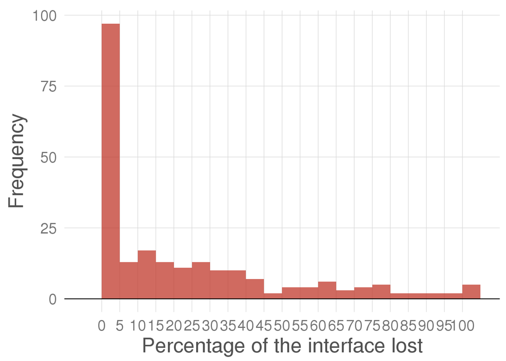

```r
ggplot(i3d_complete_uniq, aes(InteractionAffection)) +
  geom_histogram(binwidth=5,fill="#c0392b", alpha=0.75) +
  smartas_theme() +
  labs(x="Percentage of the interface lost", y="Frequency") +
  geom_hline(yintercept=0, size=0.4, color="black") +
  scale_x_continuous(breaks=seq(0,100, by=5))
```

Most of the switches do not affect the interface, or affect very little of it. However, there are some that totally disappear with the switch. Thus, even if PPI affectation is not the main mechanism involved in switch hypothetical driverness, it might play a role in many cases. If any, there might be a “bump” in the plot around the 50%, maybe marking some useful threshold. In any case, it seems like a good threshold to use…

```r
candidatesDf_agg <- read.delim(paste0(wd,"candidateList_allCancers_models_notNoise.txt"))

# split by percent of the interface affected
# Group 1: switches that affect >= 50% of the interface
# Group 2: switches that affect < 50% of the interface
x <- unique(i3d_complete_uniq[i3d_complete_uniq$InteractionAffection >= 50, c( "Gene","normalTranscript","tumorTranscript")])
colnames(x) <- c("GeneId","Normal_transcript","Tumor_transcript")
y <- unique(i3d_complete_uniq[i3d_complete_uniq$InteractionAffection < 50, c( "Gene","normalTranscript","tumorTranscript")])
colnames(y) <- c("GeneId","Normal_transcript","Tumor_transcript")

studyGroups(x,y,candidatesDf_agg)
```

```
## Size: group 1 -  30 ; group 2 -  130
## *relevance enrichment analysis
## Non significant enrichment of 1 in Group 1 and of 0 in group 2 (p = 0.37; odds ratio = 0.45)
## *CDS change enrichment analysis
## cannot be performed because there are not enough different features.
## *UTR change enrichment analysis
## Significant enrichment of 1 in Group 1 and of 0 in group 2 (p = 0.02; odds ratio = 0.37)
## *number of patients median difference test
## Non significant difference. Group 1 higher than group 2 (110.5 vs. 61.5, p = 0.18)
## *drivers enrichment analysis
## Non significant enrichment of 0 in Group 1 and of 1 in group 2 (p = 1; odds ratio = 1.17)
## *oncogene enrichment analysis
## Non significant enrichment of oncogene in Group 1 and of No in group 2 (p = 0.57; odds ratio = 0.7)
## *oncogene/suppressor enrichment analysis
## Non significant enrichment of oncogene/suppressor in Group 1 and of No in group 2 (p = 1; odds ratio = 0)
## *suppressor enrichment analysis
## Non significant enrichment of No in Group 1 and of suppressor in group 2 (p = 1; odds ratio = Inf)
## *Unknown enrichment analysis
## Non significant enrichment of Unknown in Group 1 and of No in group 2 (p = 0.57; odds ratio = 0.7)
## *d1 enrichment analysis
## Non significant enrichment of d1 in Group 1 and of Nothing in group 2 (p = 0.67; odds ratio = 0.83)
## *Driver enrichment analysis
## Non significant enrichment of Nothing in Group 1 and of Driver in group 2 (p = 1; odds ratio = 1.09)
## *hallmark enrichment analysis
## Non significant enrichment of No in Group 1 and of Hallmark in group 2 (p = 0.54; odds ratio = 0.76)
## *number of tumors median difference test
## Non significant difference. Group 1 higher than group 2 (5 vs. 4.5, p = 0.51)
```

```r
# split by percent of the interface affected
# Group 1: switches that affect >= 50% of the interface
# Group 2: all the other switches
x <- unique(i3d_complete_uniq[i3d_complete_uniq$InteractionAffection >= 50, c( "Gene","normalTranscript","tumorTranscript")])
colnames(x) <- c("GeneId","Normal_transcript","Tumor_transcript")
y <- candidatesDf_agg[! candidatesDf_agg$GeneId %in% x$GeneId &
                      ! candidatesDf_agg$Normal_transcript %in% x$Normal_transcript &
                      ! candidatesDf_agg$Tumor_transcript %in% x$Tumor_transcript &
                        as.logical(candidatesDf_agg$IsRelevant),
                      c("GeneId","Normal_transcript","Tumor_transcript")]

studyGroups(x,y,candidatesDf_agg)
```

```
## Size: group 1 -  30 ; group 2 -  4694
## *relevance enrichment analysis
## Significant enrichment of 0 in Group 1 and of 1 in group 2 (p = 0; odds ratio = Inf)
## *CDS change enrichment analysis
## cannot be performed because there are not enough different features.
## *UTR change enrichment analysis
## Non significant enrichment of 0 in Group 1 and of 1 in group 2 (p = 0.3; odds ratio = 1.48)
## *number of patients median difference test
## Significant difference. Group 1 higher than group 2 (110.5 vs. 36, p = 0)
## *drivers enrichment analysis
## Non significant enrichment of 0 in Group 1 and of 1 in group 2 (p = 1; odds ratio = 1.31)
## *oncogene enrichment analysis
## Non significant enrichment of oncogene in Group 1 and of No in group 2 (p = 1; odds ratio = 0.96)
## *oncogene/suppressor enrichment analysis
## Non significant enrichment of No in Group 1 and of oncogene/suppressor in group 2 (p = 1; odds ratio = Inf)
## *suppressor enrichment analysis
## Non significant enrichment of No in Group 1 and of suppressor in group 2 (p = 1; odds ratio = Inf)
## *Unknown enrichment analysis
## Non significant enrichment of Unknown in Group 1 and of No in group 2 (p = 0.52; odds ratio = 0.71)
## *d1 enrichment analysis
## Non significant enrichment of d1 in Group 1 and of Nothing in group 2 (p = 0.21; odds ratio = 0.6)
## *Driver enrichment analysis
## Non significant enrichment of Nothing in Group 1 and of Driver in group 2 (p = 1; odds ratio = 1.11)
## *hallmark enrichment analysis
## Significant enrichment of Hallmark in Group 1 and of No in group 2 (p = 0.01; odds ratio = 2.47)
## *number of tumors median difference test
## Significant difference. Group 1 higher than group 2 (5 vs. 2, p = 0)
```

Testing the group with affectation >= 50% against the rest of the relevant switches is juicier.